# Problem Set 06

# Question 10

What was the observed `income` value for Maine (ID2)? What was the prediction for Maine according to our model? What is the residual? Did our model over or underestimate the median income for this state?

**Answer:** observed: 51710

predicted: 57752.93

this was an over prediction

the residual was -6042.926

```r
get_regression_points(med_income_model)
```

[output not shown]

## Indpendent analysis

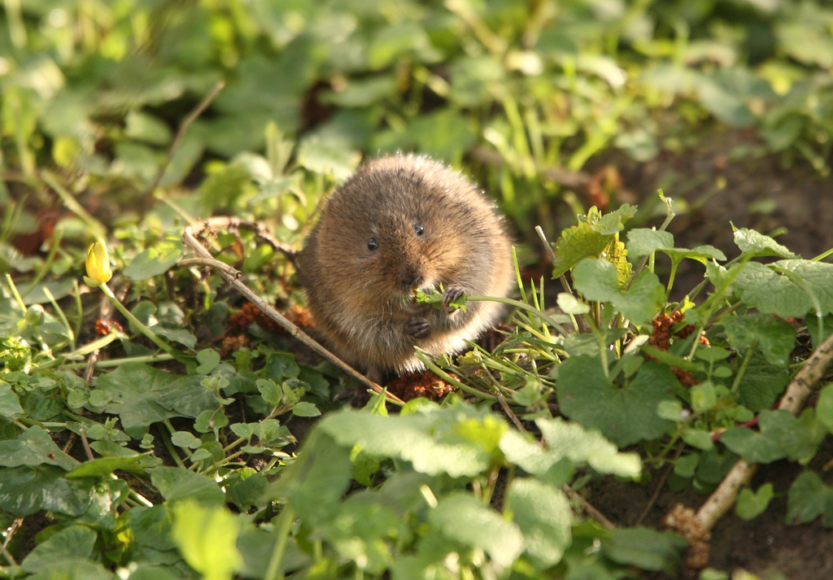

You will now use the tools you have learned, and a new data set to solve a conservation problem.

Wildlife biologists are interested in managing/protecting habitats for a declining species of vole, but are not sure about what habitats it prefers. Two things that biologists can easily control with management is percent cover of vegetation, and where habitat improvements occur (i.e. is it important to create/protect habitat in moist or dry sites, etc). To help inform habitat management of this vole species, the researchers in this study counted the number of `voles` at 56 random study sites. At each site, they measured percent cover of `veg`etation, and recorded whether a site had moist or dry `soil`.

The data can be read in like so

```r
vole_trapping <- read_csv("http://bit.ly/2IgDF0E")
```

The data contains the variables:

- `site` for the id of each random study site (each case or row is a survey/trapping site)
- `voles` for the vole count at each site
- `veg` for the percent cover of vegetation at each site
- `soil` identifying a site as “moist” or “dry”

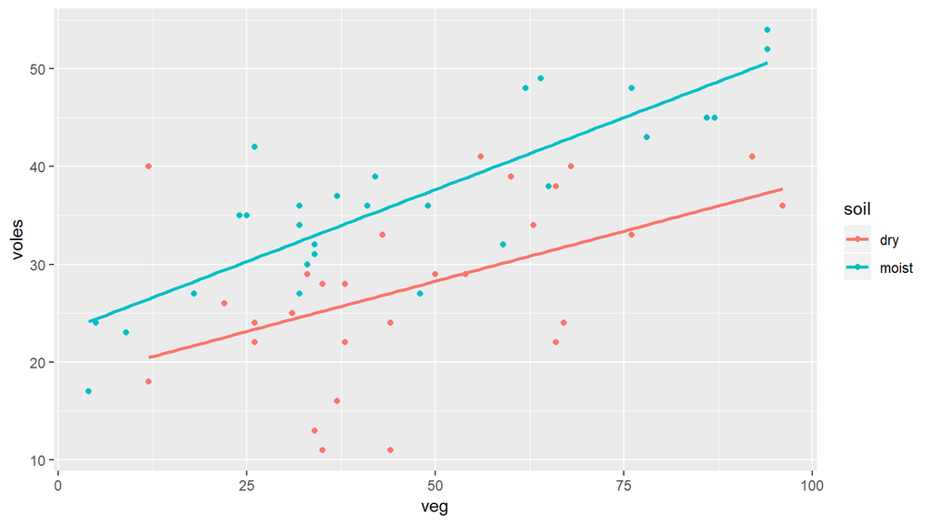

```r
ggplot(data = vole_trapping, aes(x = veg, y = voles, color = soil)) +
  geom_point() +
  geom_smooth(method = "lm", se = F)
```

```r
mod <- lm(voles ~ soil + veg, data = vole_trapping)
get_regression_table(mod)
```

| term | estimate | std_error | statistic | p_value | lower_ci | upper_ci |
| --- | --- | --- | --- | --- | --- | --- |
| intercept | 15.464 | 2.197 | 7.039 | 0 | 11.058 | 19.870 |
| soilmoist | 9.100 | 1.800 | 5.057 | 0 | 5.491 | 12.710 |
| veg | 0.259 | 0.038 | 6.840 | 0 | 0.183 | 0.335 |

# Question 11

Would you recommend to a manager that they try to protect sites with high or low vegetation cover? Why?

**Answer:** high vegetation cover…as veg cov goes up, # moles goes up

# Question 12

Dry sites are typically a lot less money to purchase and maintain for conservation organizations. Thus, if a conservation organization decides to purchase a few dry sites, roughly what percent cover of vegetation do they need to maintain on these sites (at a minimum) to support a population of about 30 voles at the site?

**Answer** Eyeballing it from the graph, ~ 55%

# Question 13

The Nature Conservancy is looking at purchasing a site for this species (in the same study area) that has moist soil and 40% vegetation cover. **Using the regression equation** what would you predict as the possible vole population the site might be able to support?

```r
15.46 + (0.259 * 40) + (9.1 *1)
```

```
## [1] 34.92
```

**Answer:** 34 or 35 critters